# Assignment 2 in D7055E Data Visualization (LTU): Geospatial libraries of Python

## Group members

Lars-Erik Englund, Emelie Berggren, Daniel Habte Medhanie. Emma Nilsson

# Our collaboration in the group

Everyone in the group conducted Part#2 and Part#3 in the lab individually. In our group we then discussed Part#2 as well as Part#3. We elaborated considerably more on Part#3 ("Challenging Questions") compared to the questions of Part#2, particularily the Voronoi diagram where everyone had their own solution suggestions which were discussed and compared. Everyone has contributed equally to the result. We have tried to improve our work based on the feed-back recieved in class compared to Assignment 1. However, we have not been able to make adjustments based on any specific feed-back from Assignment 1.

# 4 Part#2

## 4.3 Visualizing Spatial Data

**4.3.1 Create a Gaussian disc’s array with values somewhere in the range of 0 and 8 with 10 rows and 15 columns**

```python
import numpy as np

rows = 10
columns = 15
x, y = np.meshgrid(np.linspace(-1, 1, columns), np.linspace(-1, 1, rows))
d = np.sqrt(x**2 + y**2)
sigma = 0.5
myGaussianDisc = (8 * np.exp(- (d**2) / (2.0 * sigma**2))).astype('uint8')

display(myGaussianDisc)
```

```
array([[0, 0, 0, 0, 0, 0, 1, 1, 1, 0, 0, 0, 0, 0, 0],
       [0, 0, 0, 1, 1, 2, 2, 2, 2, 2, 1, 1, 0, 0, 0],
       [0, 0, 1, 2, 2, 3, 4, 4, 4, 3, 2, 2, 1, 0, 0],
       [0, 1, 2, 3, 4, 5, 6, 6, 6, 5, 4, 3, 2, 1, 0],
       [1, 1, 2, 4, 5, 6, 7, 7, 7, 6, 5, 4, 2, 1, 1],
       [1, 1, 2, 4, 5, 6, 7, 7, 7, 6, 5, 4, 2, 1, 1],
       [0, 1, 2, 3, 4, 5, 6, 6, 6, 5, 4, 3, 2, 1, 0],
       [0, 0, 1, 2, 2, 3, 4, 4, 4, 3, 2, 2, 1, 0, 0],
       [0, 0, 0, 1, 1, 2, 2, 2, 2, 2, 1, 1, 0, 0, 0],
       [0, 0, 0, 0, 0, 0, 1, 1, 1, 0, 0, 0, 0, 0, 0]], dtype=uint8)
```

**4.3.2 Extract the value of the element at x=3 and y=5.**

```python
x = 3
y = 5
display(myGaussianDisc[x,y])
```

```
5
```

The value of the element on x=3 and y=5 is 5.

**4.3.3 Install and import matplotlib and seaborn**

```python
import seaborn as sns
import matplotlib.pyplot as plt
```

**4.3.4 Create a figure with two subplots, display the defined arrays as a grayscale image and display them as a heatmap**

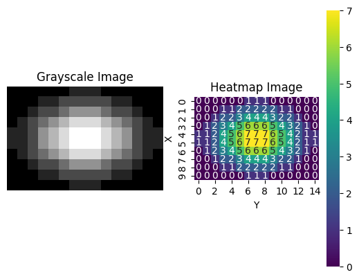

```python
f,axes = plt.subplots(1,2)
(aGrayscale, aHeatmap) = axes.flatten()

aGrayscale.imshow(myGaussianDisc, cmap="gray")
aGrayscale.set_axis_off()
aGrayscale.set_title("Grayscale Image")

sns.heatmap(myGaussianDisc,cmap="viridis",square=True,annot=True,ax=aHeatmap)
aHeatmap.set_ylim(0,10)
aHeatmap.invert_yaxis()
aHeatmap.set_ylabel('X')
aHeatmap.set_xlabel('Y')
aHeatmap.set_title("Heatmap Image")

plt.show()
```

**4.3.5 A 3-channel Gaussian disc's array with values somewhere in the range of 0 and 8 with 10 rows and 15 columns, for color images**

```python
# Define dimensions of the grid
rows = 10
columns = 15

# Create a 2D coordinate grid using meshgrid
x, y = np.meshgrid(np.linspace(-1,1,columns), np.linspace(-1,1,rows))

# Calculate the distance from origin (0,0) for each point using Pythagorean theorem
d = np.sqrt(x*x+y*y)

# Define standard deviation for the Gaussian distribution
sigma = 0.5

# Create a 2D Gaussian disc:
disc = (8*np.exp(-( (d)**2 / ( 2.0 * sigma**2 ) ))).astype('uint')

# Create an RGB color array by stacking three versions of the disc:
# Original disc for red channel
# Rolled (shifted) disc by 2 positions along axis 0 for green channel
# Rolled disc by 2 positions along axis 1 for blue channel
# axis=2 means we're stacking these as color channels (R,G,B)
myRGBColorArray = np.stack((disc,np.roll(disc,2,axis=0),np.roll(disc,2,axis=1)),axis=2)

# Print and display the Green channel (index 1) of the RGB array
print("Green:")
display(myRGBColorArray[:,:,1])
```

```
Green:
```

```
array([[0, 0, 0, 1, 1, 2, 2, 2, 2, 2, 1, 1, 0, 0, 0],
       [0, 0, 0, 0, 0, 0, 1, 1, 1, 0, 0, 0, 0, 0, 0],
       [0, 0, 0, 0, 0, 0, 1, 1, 1, 0, 0, 0, 0, 0, 0],
       [0, 0, 0, 1, 1, 2, 2, 2, 2, 2, 1, 1, 0, 0, 0],
       [0, 0, 1, 2, 2, 3, 4, 4, 4, 3, 2, 2, 1, 0, 0],
       [0, 1, 2, 3, 4, 5, 6, 6, 6, 5, 4, 3, 2, 1, 0],
       [1, 1, 2, 4, 5, 6, 7, 7, 7, 6, 5, 4, 2, 1, 1],
       [1, 1, 2, 4, 5, 6, 7, 7, 7, 6, 5, 4, 2, 1, 1],
       [0, 1, 2, 3, 4, 5, 6, 6, 6, 5, 4, 3, 2, 1, 0],
       [0, 0, 1, 2, 2, 3, 4, 4, 4, 3, 2, 2, 1, 0, 0]], dtype=uint32)
```

myRGBColorArray[:,:,1] visar hela den GRÖNA kanalen av bilden.

**4.3.6 Presentation of a gray, gray-scaled, Viridis, Hot, diverging colormap, and HSV not perceptually uniform plot**

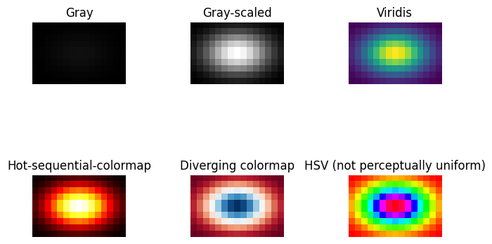

```python
# Create 2D coordinate grid from -1 to 1
x, y = np.meshgrid(np.linspace(-1,1,columns), np.linspace(-1,1,rows))

# Calculate distance from origin for each point
d = np.sqrt(x*x+y*y)

# Define standard deviation for Gaussian distribution
sigma = 0.5

# Create 12-bit Gaussian array (values 0-4095)
# 2**12-1 = 4095 (maximum value for 12 bits)
# Convert to 16-bit unsigned integer type
my12BitArray = ((2**12-1)*np.exp(-( (d)**2 / ( 2.0 * sigma**2 ) ) )).astype('uint16')

# Create subplot grid with 2 rows and 3 columns with increased spacing
f, axes = plt.subplots(2, 3, figsize=(7.5, 5))
# Add space between subplots to enhance perception
plt.subplots_adjust(wspace=0.7, hspace=0.3)

(aG, aS, aV, aH, aRB, aHSV) = axes.flatten()

aG.imshow(my12BitArray, cmap="gray", vmin=0, vmax=(2**16)-1)
aG.set_axis_off()
aG.set_title("Gray")

aS.imshow(my12BitArray, cmap="gray")
aS.set_axis_off()
aS.set_title("Gray-scaled")

aV.imshow(my12BitArray, cmap="viridis")
aV.set_axis_off()
aV.set_title("Viridis")

aH.imshow(my12BitArray, cmap="hot")
aH.set_axis_off()
aH.set_title("Hot-sequential-colormap")

aRB.imshow(my12BitArray, cmap="RdBu")
aRB.set_axis_off()
aRB.set_title("Diverging colormap")

aHSV.imshow(my12BitArray, cmap="hsv")
aHSV.set_axis_off()
aHSV.set_title("HSV (not perceptually uniform)")

plt.show()
```

## 4.5.2 Plotting and Visualizing Geospatial Data

**4.5.2.5 Import of necessary packages**

```python
import geoplot as gplt # Geoplot: Library for high-level geospatial data visualization
import geopandas as gpd # GeoPandas: Extends pandas to handle geometric/geographic data
import geoplot.crs as gcrs # Geoplot color ramp schemes for geographic visualizations
import imageio # Imageio: Library for reading and writing image data
import pandas as pd # Pandas: Data manipulation and analysis library
import pathlib # Pathlib: Object-oriented filesystem paths
import matplotlib.animation as animation # Matplotlib animation: For creating animated visualizations
import matplotlib.pyplot as plt # Matplotlib pyplot: Plotting library for creating static visualizations
import mapclassify as mc # Mapclassify: Classification schemes for choropleth maps
import numpy as np # NumPy: Library for numerical computing in Python
import pycountry # Pycountry: Database of country information (names, ISO codes, etc.)
import plotly.express as px # Plotly Express: High-level interface for creating interactive plots
```

**4.5.2.6 Jupyter notebook command to be sure to run the following command to render plots properly**

```python
%matplotlib inline
```

**4.5.2.7 Load a shapefile and view parts of it**

```python
usa = gpd.read_file("C:\\Users\\emmae\\Desktop\\DataVisualization_Uppgiftsmapp\\Labb2\\3.3NationalObesityByState\\us_state.shp")
print(usa.head())
```

```
   OBJECTID   FIPS  FIPSNum StateFIPS  StateFIPSN   StateName  CensusReg  \
0         1  02000     2000        02           2      Alaska       West
1         9  53000    53000        53          53  Washington       West
2        10  23000    23000        23          23       Maine  Northeast
3        11  27000    27000        27          27   Minnesota    Midwest
4        18  26000    26000        26          26    Michigan    Midwest

            CensusDiv     XCentroid     YCentroid Notes  \
0             Pacific -1.882092e+06  2.310348e+06  None
1             Pacific -1.837353e+06  1.340481e+06  None
2         New England  2.068850e+06  1.172787e+06  None
3  West North Central  1.310476e+05  9.821300e+05  None
4  East North Central  8.425679e+05  8.094373e+05  None

                                            geometry
0  MULTIPOLYGON (((-2247528.774 2237995.012, -224...
1  MULTIPOLYGON (((-2124362.243 1480441.851, -212...
2  MULTIPOLYGON (((1951177.135 1127914.539, 19511...
3  POLYGON ((-91052.168 1282100.079, -30035.391 1...
4  MULTIPOLYGON (((764918.731 786184.882, 772386....
```

**4.5.2.8 Load the US Census data as a pandas DataFrame and view a portion of it**

```python
state_pop = pd.read_csv("C:\\Users\\emmae\\Desktop\\DataVisualization_Uppgiftsmapp\\Labb2\\3.3GeospatialDataVisualization\\us_state_est_population.csv")
print(state_pop.head())
```

```
   SUMLEV REGION DIVISION  STATE              NAME  CENSUS2010POP  \
0      10      0        0      0     United States      308745538
1      20      1        0      0  Northeast Region       55317240
2      20      2        0      0    Midwest Region       66927001
3      20      3        0      0      South Region      114555744
4      20      4        0      0       West Region       71945553

   ESTIMATESBASE2010  POPESTIMATE2010  POPESTIMATE2011  POPESTIMATE2012  ...  \
0          308758105        309326085        311580009        313874218  ...
1           55318430         55380645         55600532         55776729  ...
2           66929743         66974749         67152631         67336937  ...
3          114563045        114867066        116039399        117271075  ...
4           71946887         72103625         72787447         73489477  ...

   RDOMESTICMIG2017  RDOMESTICMIG2018  RNETMIG2011  RNETMIG2012  RNETMIG2013  \
0          0.000000          0.000000     2.553948     2.746049     2.701727
1         -5.651919         -5.222289     0.845134     0.040762    -0.397011
2         -2.370672         -2.301663    -1.043009    -0.896575     0.042505
3          2.963135          2.779373     5.379667     5.836112     5.290067
4          1.478565          1.350094     2.689358     3.226360     3.343874

   RNETMIG2014  RNETMIG2015  RNETMIG2016  RNETMIG2017  RNETMIG2018
0     2.988276     3.328598     3.321549     2.941086     3.001086
1    -0.923951    -2.011735    -2.430459    -1.801582    -1.127222
2    -0.715656    -1.357662    -1.226811    -0.519621    -0.431833
3     6.206402     7.328494     7.225046     6.252425     6.148925
4     4.148127     5.127995     5.372314     4.164981     3.965769

[5 rows x 136 columns]
```

**4.5.2.9 Merge the shapefile "usa" with population data "state_pop", joining on the state names**

```python
#Couples state name and region name
pop_states = usa.merge(state_pop, left_on="StateName", right_on="NAME")
pop_states.head()
```

|  | OBJECTID | FIPS | FIPSNum | StateFIPS | StateFIPSN | StateName | CensusReg | CensusDiv | XCentroid | YCentroid | ... | RDOMESTICMIG2017 | RDOMESTICMIG2018 | RNETMIG2011 | RNETMIG2012 | RNETMIG2013 | RNETMIG2014 | RNETMIG2015 | RNETMIG2016 | RNETMIG2017 | RNETMIG2018 |
| --- | --- | --- | --- | --- | --- | --- | --- | --- | --- | --- | --- | --- | --- | --- | --- | --- | --- | --- | --- | --- | --- |
| 0 | 1 | 02000 | 2000 | 02 | 2 | Alaska | West | Pacific | -1.882092e+06 | 2.310348e+06 | ... | -14.508975 | -14.557034 | 0.474949 | 1.496795 | -0.903612 | -11.375421 | -7.968225 | -3.911968 | -11.005272 | -11.306342 |
| 1 | 9 | 53000 | 53000 | 53 | 53 | Washington | West | Pacific | -1.837353e+06 | 1.340481e+06 | ... | 8.785531 | 6.222703 | 6.178750 | 4.988577 | 4.920545 | 7.646476 | 10.698382 | 13.260274 | 13.025173 | 10.307584 |
| 2 | 10 | 23000 | 23000 | 23 | 23 | Maine | Northeast | New England | 2.068850e+06 | 1.172787e+06 | ... | 3.517808 | 3.343224 | 0.774160 | -0.262817 | 0.872778 | 2.531821 | -0.488109 | 3.352064 | 3.952096 | 3.769637 |
| 3 | 11 | 27000 | 27000 | 27 | 27 | Minnesota | Midwest | West North Central | 1.310476e+05 | 9.821300e+05 | ... | 1.370050 | 1.210984 | 1.244122 | 0.452332 | 1.825538 | 1.725691 | 0.855495 | 2.536818 | 3.311345 | 3.128451 |
| 4 | 18 | 26000 | 26000 | 26 | 26 | Michigan | Midwest | East North Central | 8.425679e+05 | 8.094373e+05 | ... | -1.306782 | -1.678920 | -2.061435 | -0.849915 | -0.452896 | -0.497986 | -1.506507 | 0.103498 | 0.842519 | 0.465543 |

5 rows × 148 columns

**4.5.2.10 Plot a shape for California**

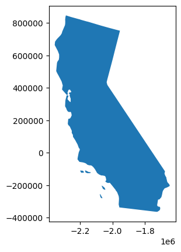

```python
pop_states[pop_states.NAME=="California"].plot()
```

**4.5.2.11 A GeoDataFrame (a DataFrame with geospatial data) in its place. (Generated by loading one of the sample datasets from geoplot, in this case, the polygons for state boundaries)**

```python
path = gplt.datasets.get_path("contiguous_usa")
contiguous_usa = gpd.read_file(path)
contiguous_usa.head()
```

|  | state | adm1_code | population | geometry |
| --- | --- | --- | --- | --- |
| 0 | Minnesota | USA-3514 | 5303925 | POLYGON ((-89.59941 48.01027, -89.48888 48.013... |
| 1 | Montana | USA-3515 | 989415 | POLYGON ((-111.19419 44.56116, -111.29155 44.7... |
| 2 | North Dakota | USA-3516 | 672591 | POLYGON ((-96.60136 46.35136, -96.53891 46.199... |
| 3 | Idaho | USA-3518 | 1567582 | POLYGON ((-111.04973 44.48816, -111.05024 42.0... |
| 4 | Washington | USA-3519 | 6724540 | POLYGON ((-116.99807 46.33017, -116.90653 46.1... |

**4.5.2.12 Plot the map of the US**

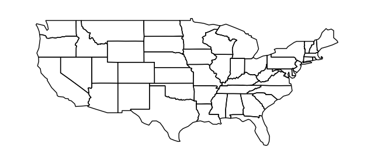

```python
gplt.polyplot(contiguous_usa)
```

The result displays a simple map where each state is represented as a polygon. contiguous_usa is a GeoPandas DataFrame containing the 48 contiguous states.

**4.5.2.13 Another sample dataset, in this case for US cities**

```python
path = gplt.datasets.get_path("usa_cities")
usa_cities = gpd.read_file(path)
usa_cities.head()
```

|  | id | POP_2010 | ELEV_IN_FT | STATE | geometry |
| --- | --- | --- | --- | --- | --- |
| 0 | 53 | 40888.0 | 1611.0 | ND | POINT (-101.29627 48.23251) |
| 1 | 101 | 52838.0 | 830.0 | ND | POINT (-97.03285 47.92526) |
| 2 | 153 | 15427.0 | 1407.0 | ND | POINT (-98.70844 46.91054) |
| 3 | 177 | 105549.0 | 902.0 | ND | POINT (-96.7898 46.87719) |
| 4 | 192 | 17787.0 | 2411.0 | ND | POINT (-102.78962 46.87918) |

**4.5.2.14 The locations of each city in the continental US as points**

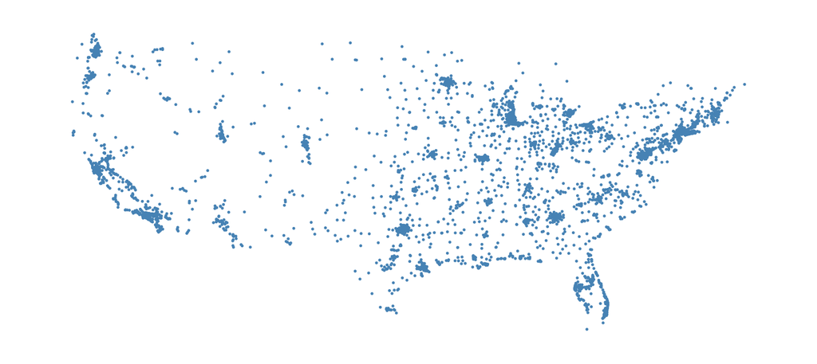

```python
continental_usa_cities = usa_cities.query('STATE not in ["HI", "AK", "PR"]')
gplt.pointplot(continental_usa_cities, s=3, figsize=(20,15))
```

Display all cities in the US. Note that HI (Hawaii), AK (Alaska) and PR (Puerto Rico) was excluded in the usa_cities dataframe. We shrank the size of the points and increased the size of the map to enhance the visualization.

**4.5.2.15 Combining state polygons and city dots (using overplotting) to show the cities and states in the continental US.**

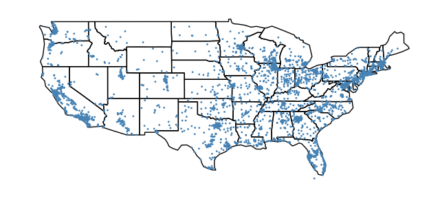

```python
ax = gplt.polyplot(contiguous_usa)
gplt.pointplot(continental_usa_cities, s=1, ax=ax)
```

We decided to reduce the size of the dots so they wouldn't hide the state boarders.

**4.5.2.16 Adjustment of the projection because of the stretched appearance**

```
<GeoAxes: >
```

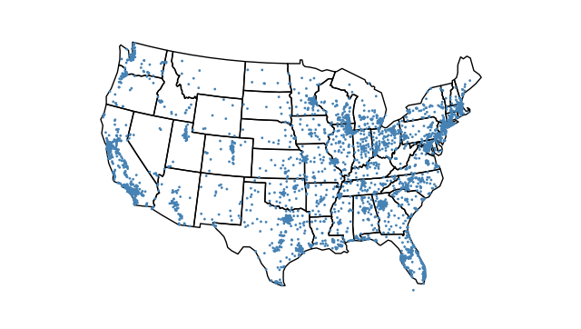

```python
ax = gplt.polyplot(contiguous_usa, projection=gcrs.AlbersEqualArea())
gplt.pointplot(continental_usa_cities, s= 1, ax=ax)
```

Now the map looks more familiar.

**4.5.2.17 Comparision of several different ways to visualize geospatial data:**

- change the color of a city’s plotted point based on its elevation over sea
- add a legend for people to decode the meaning of the different colors

```
<GeoAxes: >
```

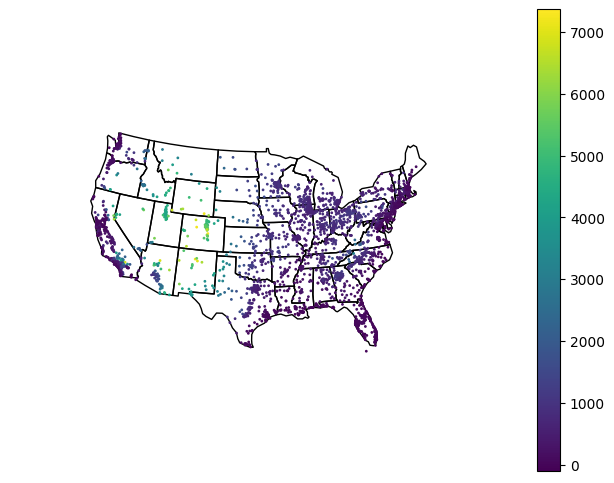

```python
ax = gplt.polyplot(contiguous_usa, projection=gcrs.AlbersEqualArea())
gplt.pointplot(
    continental_usa_cities,
    ax=ax,
    s=1,
    hue="ELEV_IN_FT",
    legend=True

)
```

Yellow/green dots are more elevated than blue/purple dots as indicated by the legend to the right.

**4.5.2.18 Use the scale (elevation) of each plotted point to represent another dimension**

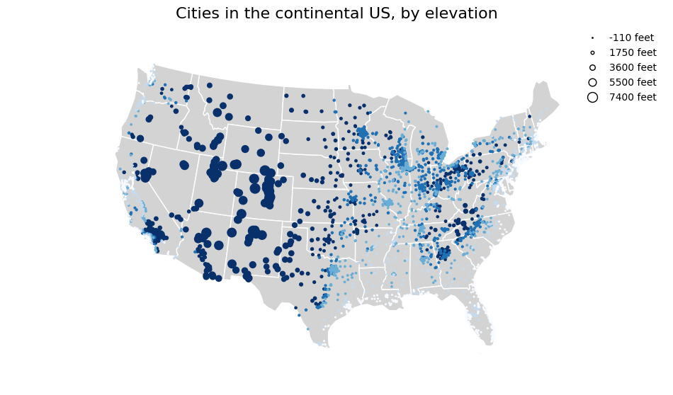

```python
ax = gplt.polyplot(
    contiguous_usa,
    edgecolor="white",
    facecolor="lightgray",
    figsize=(12, 8),
    projection=gcrs.AlbersEqualArea()
)

gplt.pointplot(
    continental_usa_cities,
    ax=ax,
    hue="ELEV_IN_FT",
    cmap="Blues",
    scheme="quantiles",
    scale="ELEV_IN_FT",
    limits=(1, 10),
    legend=True,
    legend_var="scale",
    legend_kwargs={"frameon": False},
    legend_values=[-110, 1750, 3600, 5500, 7400],
    legend_labels=["-110 feet", "1750 feet", "3600 feet", "5500 feet", "7400 feet"]
)

ax.set_title("Cities in the continental US, by elevation", fontsize=16)
```

This creates a dual visual representation of elevation data - both through color and point size. This can make it easier to perceive elevation differences in the data. Larger and darker points represents higher elevation.

**4.5.2.19 With a choropleth different hues or colors to shade polygons are used to represent a dimension of data**

```
<GeoAxes: >
```

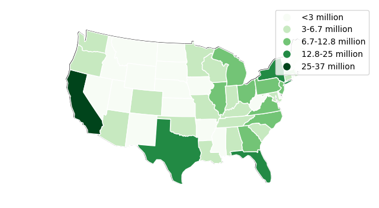

```python
ax = gplt.polyplot(contiguous_usa, projection=gcrs.AlbersEqualArea())
gplt.choropleth(
    contiguous_usa,
    hue="population",
    edgecolor="white",
    linewidth=1,
    cmap="Greens",
    legend=True,
    scheme="FisherJenks",
    legend_labels=[
        "<3 million", "3-6.7 million", "6.7-12.8 million",
        "12.8-25 million", "25-37 million"
    ],
    projection=gcrs.AlbersEqualArea(),
    ax=ax
)
```

We see colors (green shades, white boundaries) for each state based on population size. Population data has been divided into categories using the Fisher-Jenks method. More people are living along the utter borders than inside the country.

**5.4.2.20 Work with data associated with areas of polygons: load a dataset about obesity rates by US state**

```python
obesity = pd.read_csv(gplt.datasets.get_path("obesity_by_state"), sep="\t")
obesity.head()
```

|  | State | Percent |
| --- | --- | --- |
| 0 | Alabama | 32.4 |
| 1 | Missouri | 30.4 |
| 2 | Alaska | 28.4 |
| 3 | Montana | 24.6 |
| 4 | Arizona | 26.8 |

**5.4.2.21 Convert that into a GeoDataFrame using a join (will add the required "geometry" column)**

```python
geo_obesity = contiguous_usa.set_index("state").join(obesity.set_index("State"))
geo_obesity.head()
```

| state | adm1_code | population | geometry | Percent |
| --- | --- | --- | --- | --- |
| Minnesota | USA-3514 | 5303925 | POLYGON ((-89.59941 48.01027, -89.48888 48.013... | 25.5 |
| Montana | USA-3515 | 989415 | POLYGON ((-111.19419 44.56116, -111.29155 44.7... | 24.6 |
| North Dakota | USA-3516 | 672591 | POLYGON ((-96.60136 46.35136, -96.53891 46.199... | 31.0 |
| Idaho | USA-3518 | 1567582 | POLYGON ((-111.04973 44.48816, -111.05024 42.0... | 29.6 |
| Washington | USA-3519 | 6724540 | POLYGON ((-116.99807 46.33017, -116.90653 46.1... | 27.2 |

**5.4.2.22 Use this data to plot a cartogram, which grows or shrinks polygons to represent a dimension of data – i.e. the obesity rates per state**

```
<GeoAxes: >
```

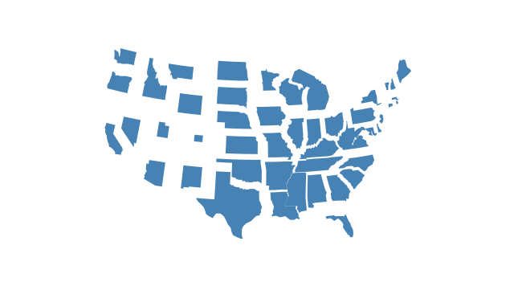

```python
gplt.cartogram(
    geo_obesity,
    scale="Percent",
    projection=gcrs.AlbersEqualArea()
)
```

**4.5.2.23 Create a Voronoi diagram that calculates polygon areas based on a dimension of the data (here locations of primary schools in Melbourne, Australia). Each polygon is positioned based on a creating point, with the end goal that each area in the polygon is nearer to its creating point than to some other.**

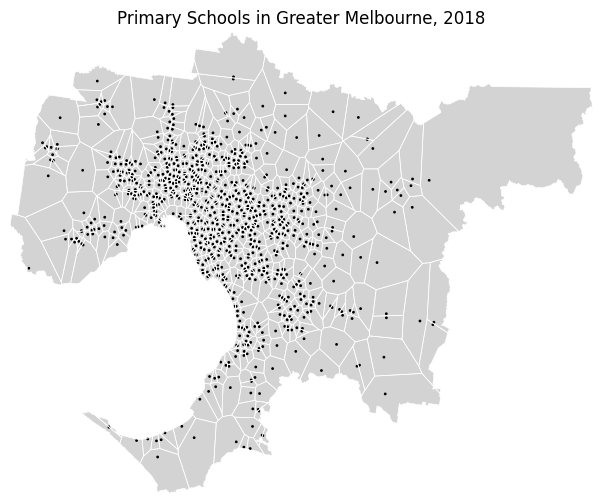

```python
# Load data
melbourne = gpd.read_file(gplt.datasets.get_path("melbourne"))
df = gpd.read_file(gplt.datasets.get_path("melbourne_schools"))
melbourne_primary_schools = df.query('School_Type == "Primary"')

# Create Voronoi diagram for school catchment areas
ax = gplt.voronoi(
    melbourne_primary_schools,
    clip=melbourne,
    linewidth=0.5,
    edgecolor="white",
    projection=gcrs.Mercator(),
)

# Add Melbourne as background
gplt.polyplot(
    melbourne,
    edgecolor="None",
    facecolor="lightgray",
    ax=ax
)

# Plot schools as points
gplt.pointplot(
    melbourne_primary_schools,
    color="black",
    ax=ax,
    s=1,
    extent=melbourne.total_bounds
)

# Add title
plt.title("Primary Schools in Greater Melbourne, 2018")
```

## 4.6 Covid-19 Visualization

**4.6.2 Load dataset with confirmed global Covid-19 cases**

```python
import pandas as pd
import pycountry
import plotly.express as px

df_confirmedGlobal = pd.read_csv("C:\\Users\\emmae\\Desktop\\DataVisualization_Uppgiftsmapp\\Labb2\\3.4Covid-19\\time_series_covid19_confirmed_global.csv")
print(df_confirmedGlobal.head())
```

```
  Province/State Country/Region       Lat       Long  1/22/20  1/23/20  \
0            NaN    Afghanistan  33.93911  67.709953        0        0
1            NaN        Albania  41.15330  20.168300        0        0
2            NaN        Algeria  28.03390   1.659600        0        0
3            NaN        Andorra  42.50630   1.521800        0        0
4            NaN         Angola -11.20270  17.873900        0        0

   1/24/20  1/25/20  1/26/20  1/27/20  ...  10/31/20  11/1/20  11/2/20  \
0        0        0        0        0  ...     41425    41501    41633
1        0        0        0        0  ...     20875    21202    21523
2        0        0        0        0  ...     57942    58272    58574
3        0        0        0        0  ...      4756     4825     4888
4        0        0        0        0  ...     10805    11035    11228

   11/3/20  11/4/20  11/5/20  11/6/20  11/7/20  11/8/20  11/9/20
0    41728    41814    41935    41975    42033    42092    42297
1    21904    22300    22721    23210    23705    24206    24731
2    58979    59527    60169    60800    61381    62051    62693
3     4910     5045     5135     5135     5319     5383     5437
4    11577    11813    12102    12223    12335    12433    12680

[5 rows x 297 columns]
```

**4.6.3 Clean the Dataset, make the following changes to the dataframe:**

- Aggregate the dataset into the degree of the country.
- Get the three-letter country codes for each country (using PyCountry or any other method)
- Transform the dataset in a long format in which the date value is representing in a single column (loading the dataset into the Pandas DataFrame and then using melt in Pandas)

```python
# Remove unnecessary columns and sum by country
df_confirmedGlobal = df_confirmedGlobal.drop(columns=['Province/State', 'Lat', 'Long'])
df_confirmedGlobal = df_confirmedGlobal.groupby('Country/Region').agg('sum')
date_list = list(df_confirmedGlobal.columns)

# Function to get three-letter country codes
def get_country_code(name):
    try:
        return pycountry.countries.lookup(name).alpha_3
    except:
        return None

# Add country codes to the dataset
df_confirmedGlobal['country'] = df_confirmedGlobal.index
df_confirmedGlobal['iso_alpha_3'] = df_confirmedGlobal['country'].apply(get_country_code)

# Transform to long format
df_long = pd.melt(df_confirmedGlobal,
                  id_vars=['country', 'iso_alpha_3'],
                  value_vars=date_list)
print(df_long)
```

```
                  country iso_alpha_3 variable  value
0             Afghanistan         AFG  1/22/20      0
1                 Albania         ALB  1/22/20      0
2                 Algeria         DZA  1/22/20      0
3                 Andorra         AND  1/22/20      0
4                  Angola         AGO  1/22/20      0
...                   ...         ...      ...    ...
55665  West Bank and Gaza        None  11/9/20  58838
55666      Western Sahara         ESH  11/9/20     10
55667               Yemen         YEM  11/9/20   2071
55668              Zambia         ZMB  11/9/20  16971
55669            Zimbabwe         ZWE  11/9/20   8561

[55670 rows x 4 columns]
```

An output with the requested content and format. Displays the beginning and the end of the dataset.

**4.6.4 Create Map with Plotly Express**

```python
fig = px.choropleth(df_long,
                    locations="iso_alpha_3",
                    color="value",
                    hover_name="country",
                    animation_frame="variable",
                    projection="natural earth",
                    color_continuous_scale='Peach',
                    range_color=[0, 50000]
                    )

fig.show()
fig.write_html("Covid19_map.html") # write it to HTML file
```

[output not shown]

# 5 Part#3: Challenging Questions

**Q1. Use “myRGBColorArray” from step5 in subsection Visualizing Spatial Data and display individual channels as well as Composite accordingly.**

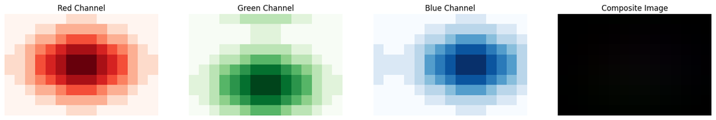

```python
# Create a figure with 4 subplots
fig, axes = plt.subplots(1, 4, figsize=(20, 5))

# Display the Red channel
axes[0].imshow(myRGBColorArray[:, :, 0], cmap='Reds')
axes[0].set_title('Red Channel')
axes[0].axis('off')

# Display the Green channel
axes[1].imshow(myRGBColorArray[:, :, 1], cmap='Greens')
axes[1].set_title('Green Channel')
axes[1].axis('off')

# Display the Blue channel
axes[2].imshow(myRGBColorArray[:, :, 2], cmap='Blues')
axes[2].set_title('Blue Channel')
axes[2].axis('off')

# Display the Composite image
axes[3].imshow(myRGBColorArray)
axes[3].set_title('Composite Image')
axes[3].axis('off')


plt.show()
```

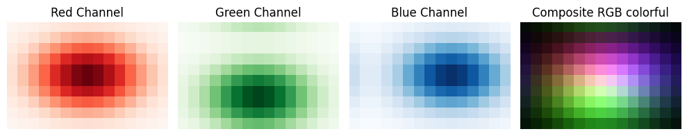

```python
rows = 10
columns = 15
x, y = np.meshgrid(np.linspace(-1, 1, columns), np.linspace(-1, 1, rows))
sigma = 0.5
d = np.sqrt(x**2 + y**2)
disc = (8 * np.exp(-(d**2 / (2.0 * sigma**2)))).astype('float32')  # Använd float för mer kontroll

#Normalisera disken mellan 0 och 255
disc = 255 * (disc / disc.max())

#Skapa RGB-array
myRGBColorArray = np.stack([
    disc,                     # Röd kanal
    np.roll(disc, 2, axis=0), # Grön kanal
    np.roll(disc, 2, axis=1)  # Blå kanal
], axis=2).astype('uint8')

#Visa bilderna
plt.figure(figsize=(10, 3))

#Röd kanal
plt.subplot(1, 4, 1)
plt.title("Red Channel")
plt.imshow(myRGBColorArray[:, :, 0], cmap='Reds')
plt.axis('off')

#Grön kanal
plt.subplot(1, 4, 2)
plt.title("Green Channel")
plt.imshow(myRGBColorArray[:, :, 1], cmap='Greens')
plt.axis('off')

#Blå kanal
plt.subplot(1, 4, 3)
plt.title("Blue Channel")
plt.imshow(myRGBColorArray[:, :, 2], cmap='Blues')
plt.axis('off')

#Kombinerad RGB-bild som blir helsvart
plt.subplot(1, 4, 4)
plt.title("Composite RGB colorful")
plt.imshow(myRGBColorArray)
plt.axis('off')

plt.tight_layout()
plt.show()
```

The first three subplots display when the emphasis is on one out of the three possible channels, either red, green or blue. The fourth subplot, the composite subplot, is made from all three channels. In our first code the composite subplot was all blanck and in the second it was more colorful. We added the second composite subplot in order to make it more esthetically appealing.

**Q2. What is quantile? How does the number of quantiles affect the visualization? (write 3-5 sentences)**

A quantile divides a dataset into equal-sized subsets based on the data's distribution. The number of quantiles determines how finely the data is partitioned and affect how patterns/distributions are visualized. When fewer quantiles are used (e.g., quartiles), the visualization highlights broader trends, making it easier to observe general patterns but not finer details. Conversely, using many quantiles reveals more nuanced or subtle variations in the data, but can make the visualization cluttered and harder to interpret. By adjusting the number of quantiles, you balance between simplicity and detail in your visualizations.

**Q3. Divide the continental_usa_cities into 10 quantiles and assign a different hue to each quantile and a legend to explain accordingly. Produce a point plot or similar plot and explain the representation difference in your own words.**

[figure not shown]

```python
#import matplotlib.pyplot as plt
import matplotlib.colors as mcolors

# Classify the data into 10 quantiles
quantiles = mc.Quantiles(continental_usa_cities['ELEV_IN_FT'], k=10)

# Add the quantile classification to the dataframe
continental_usa_cities['quantiles'] = quantiles.yb

# Create the plot
ax = gplt.polyplot(contiguous_usa, projection=gcrs.AlbersEqualArea())
gplt.pointplot(
    continental_usa_cities,
    ax=ax,
    hue='quantiles',
    cmap='viridis',
    legend=False,
    #legend_var='hue',
    s=1
)

# Create a custom legend
cmap = plt.cm.viridis
norm = mcolors.Normalize(vmin=0, vmax=9)  # Quantiles range from 0 to 9
sm = plt.cm.ScalarMappable(cmap=cmap, norm=norm)
sm.set_array([])  # Required for the colorbar to function
cbar = plt.colorbar(sm, ax=ax, orientation="vertical", pad=0.05)
# Add the title to the colorbar (acts as the legend heading)
cbar.set_label("Elevation in feet")

plt.title("US Cities Elevation Quantiles")
plt.show()
```

Representation Difference: By dividing the data into quantiles, we can clearly see how the cities are distributed across different elevation ranges. Each quantile represents a subset of the data with similar elevations, allowing us to understand the distribution and density of cities at various elevation levels. This method is effective in highlighting patterns and trends that might be missed if we were to use a single color for all data points or group them without considering the distribution. Based on the output we can conclude that Central US is higher above sea level than the coasts. Western part of the US is more elevated than the eastern part of the ocuntry.

**Q4. Create a Voronoi diagram for the elevations of US cities. Use a data smoothing technique since the elevations are for points, and "spread" those values across areas.**

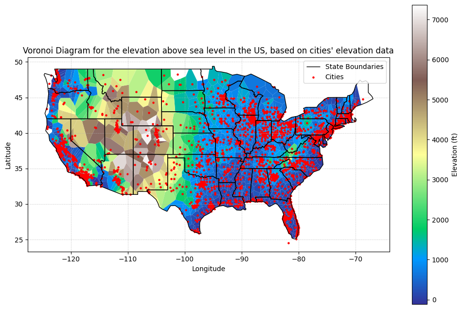

```python
import geopandas as gpd
import geoplot as gplt
from scipy.spatial import Voronoi
from shapely.geometry import Polygon, Point
import matplotlib.pyplot as plt
import numpy as np

# Load the usa_cities dataset
path = gplt.datasets.get_path("usa_cities")
usa_cities = gpd.read_file(path)

# Filter for continental US cities
continental_usa_cities = usa_cities.query('STATE not in ["HI", "AK", "PR"]')

# Extract city coordinates
points = np.array([(point.x, point.y) for point in continental_usa_cities.geometry])
elevations = continental_usa_cities["ELEV_IN_FT"].to_numpy()

# Generate valid Voronoi polygons and associate with elevations
vor = Voronoi(points)
vor_polygons = []
valid_elevations = []

for region_idx, elevation in zip(vor.point_region, elevations):
    region = vor.regions[region_idx]
    if -1 not in region and region:  # Exclude infinite or empty regions
        polygon = Polygon([vor.vertices[i] for i in region])
        if polygon.is_valid:  # Ensure the polygon is valid
            vor_polygons.append(polygon)
            valid_elevations.append(elevation)

# Create GeoDataFrame with valid polygons and corresponding elevations
polygons_with_elevation = gpd.GeoDataFrame(
    {"geometry": vor_polygons, "Elevation": valid_elevations},
    crs=continental_usa_cities.crs
)

# Load US states shapefile and compute boundary
us_states = gpd.read_file(gplt.datasets.get_path("contiguous_usa"))
us_boundary = us_states.geometry.unary_union

# Clip Voronoi polygons to the US border
clipped = gpd.overlay(
    polygons_with_elevation,
    gpd.GeoDataFrame(geometry=[us_boundary], crs=us_states.crs),
    how="intersection"
)

# Plot the Voronoi diagram colored by elevation
fig, ax = plt.subplots(figsize=(12, 8))
clipped.plot(column="Elevation", cmap="terrain", ax=ax, legend=True, legend_kwds={'label': "Elevation (ft)"})

# Plot US state boundaries
us_states.boundary.plot(ax=ax, linewidth=1, edgecolor="black", label="State Boundaries")

# Plot cities as points
continental_usa_cities.plot(ax=ax, color="red", markersize=5, label="Cities")

# Add title, legend, and axis labels
plt.title("Voronoi Diagram for the elevation above sea level in the US, based on cities' elevation data")
plt.xlabel("Longitude")
plt.ylabel("Latitude")
plt.legend(loc="upper right", frameon=True, fontsize=10)

# Show grid for better reference of latitude and longitude
ax.grid(True, linestyle='--', linewidth=0.5, alpha=0.7)

# Show the plot
plt.show()
```

The Voronoi diagram displays the region's elevation around cities in the US. Based on the data about each city the Voronoi technique suggests elevation level about larger areas/regions. We have tried to make the visualization self explainatory by describing axis, legend, keeping cities and state boarders in accurate position to eachother etc.

As the instructuion was to create a Voronoi diagram for the elevations of US cities the Voronoi diagram might not be the optimal choice to showcase indivudual cities specific elevation. It is hard to see the exact elevation of a city for three reasons. First, a city may be located on the border between two colors. Second, the legend used is based on a continuous color scale rather than based on color associated binning. Third, the Voronoi reveales additional information regarding the area between the cities. Example of an mprovement would be to make the map "interactable" so that hoovering over a city data point would give the exact elevation or use anpther visualization technique that points out seperate cities elevation. However, this kind of visualization is very informative when it comes to getting a good overwiew of the elevation of certain specific geograhic points and the elevation's variation.

**Q5. Apply the same Covid19 visualization section’s method for visualizing the COVID-19 recovered case dataset**

```python
# Load the dataset with recovered global COVID-19 cases
df_recoveredGlobal = pd.read_csv("..\\..\\3.4Covid-19\\time_series_covid19_recovered_global.csv")
print(df_recoveredGlobal.head())

# Remove unnecessary columns and sum by country
df_recoveredGlobal = df_recoveredGlobal.drop(columns=['Province/State', 'Lat', 'Long'])
df_recoveredGlobal = df_recoveredGlobal.groupby('Country/Region').agg('sum')
date_list_recovered = list(df_recoveredGlobal.columns)

# Add country codes to the dataset
df_recoveredGlobal['country'] = df_recoveredGlobal.index
df_recoveredGlobal['iso_alpha_3'] = df_recoveredGlobal['country'].apply(get_country_code)

# Transform to long format
df_long_recovered = pd.melt(df_recoveredGlobal,
                            id_vars=['country', 'iso_alpha_3'],
                            value_vars=date_list_recovered)
print(df_long_recovered)

# Create Map with Plotly Express
fig_recovered = px.choropleth(df_long_recovered,
                              locations="iso_alpha_3",
                              color="value",
                              hover_name="country",
                              animation_frame="variable",
                              projection="natural earth",
                              color_continuous_scale='Greens',
                              range_color=[0, 50000],
                              labels={"value": "Covid-19 Recovered cases", "variable": "Date"}
                              )

fig_recovered.show()
fig_recovered.write_html("Covid19_recovered_map.html") # write it to HTML file
```

```
  Province/State Country/Region       Lat       Long  1/22/20  1/23/20  \
0            NaN    Afghanistan  33.93911  67.709953        0        0
1            NaN        Albania  41.15330  20.168300        0        0
2            NaN        Algeria  28.03390   1.659600        0        0
3            NaN        Andorra  42.50630   1.521800        0        0
4            NaN         Angola -11.20270  17.873900        0        0

   1/24/20  1/25/20  1/26/20  1/27/20  ...  10/31/20  11/1/20  11/2/20  \
0        0        0        0        0  ...     34321    34326    34342
1        0        0        0        0  ...     11189    11246    11367
2        0        0        0        0  ...     40201    40395    40577
3        0        0        0        0  ...      3475     3475     3548
4        0        0        0        0  ...      4523     4920     5172

   11/3/20  11/4/20  11/5/20  11/6/20  11/7/20  11/8/20  11/9/20
```

[output cut: 21 more lines]

**Q6. Apply the same Covid19 visualization section’s method for visualizing the COVID-19 death case dataset**

```python
# Load the dataset with global COVID-19 death cases
df_deathsGlobal = pd.read_csv("..\\..\\3.4Covid-19\\time_series_covid19_deaths_global.csv")
print(df_deathsGlobal.head())

# Remove unnecessary columns and sum by country
df_deathsGlobal = df_deathsGlobal.drop(columns=['Province/State', 'Lat', 'Long'])
df_deathsGlobal = df_deathsGlobal.groupby('Country/Region').agg('sum')
date_list_deaths = list(df_deathsGlobal.columns)

# Add country codes to the dataset
df_deathsGlobal['country'] = df_deathsGlobal.index
df_deathsGlobal['iso_alpha_3'] = df_deathsGlobal['country'].apply(get_country_code)

# Transform to long format
df_long_deaths = pd.melt(df_deathsGlobal,
                         id_vars=['country', 'iso_alpha_3'],
                         value_vars=date_list_deaths)
print(df_long_deaths)

# Create Map with Plotly Express
fig_deaths = px.choropleth(df_long_deaths,
                           locations="iso_alpha_3",
                           color="value",
                           hover_name="country",
                           animation_frame="variable",
                           projection="natural earth",
                           color_continuous_scale='Reds',
                           range_color=[0, 50000],
                           labels={"value": "Covid-19 Death cases", "variable": "Date"}
                           )

fig_deaths.show()
fig_deaths.write_html("Covid19_deaths_map.html") # write it to HTML file
```

```
  Province/State Country/Region       Lat       Long  1/22/20  1/23/20  \
0            NaN    Afghanistan  33.93911  67.709953        0        0
1            NaN        Albania  41.15330  20.168300        0        0
2            NaN        Algeria  28.03390   1.659600        0        0
3            NaN        Andorra  42.50630   1.521800        0        0
4            NaN         Angola -11.20270  17.873900        0        0

   1/24/20  1/25/20  1/26/20  1/27/20  ...  10/31/20  11/1/20  11/2/20  \
0        0        0        0        0  ...      1536     1536     1541
1        0        0        0        0  ...       509      518      527
2        0        0        0        0  ...      1964     1973     1980
3        0        0        0        0  ...        75       75       75
4        0        0        0        0  ...       284      286      289

   11/3/20  11/4/20  11/5/20  11/6/20  11/7/20  11/8/20  11/9/20
```

[output cut: 21 more lines]